# Análisis Multivariado - Clase 9

2025-10-07

## Tablas de contingencia

## Motivación

- Parrillero en un cuadrangular del ascenso

```
##    ArMer DoSu Fén Sac
## Ch     8    1   6   1
## Pa     0    0   2   2
## Bo     1    8   1   6
```

Llamamos a esta tabla de contingencia \(X\)

- ¿Son independientes los consumos de los hinchas de distintos clubes?

## Marginales

Si fueran independientes, para cada combinación debería cumplirse: \[p_{i,j}=p_i\cdot p_j\]

Para eso tendríamos que estimar cuán frecuente es cada combinación, pero también el consumo de cada alimento y la alfuencia de hinchas de cada club.

```
##      ArMer DoSu Fén Sac rSum
## Ch       8    1   6   1   16
## Pa       0    0   2   2    4
## Bo       1    8   1   6   16
## cSum     9    9   9   9   36
```

## Frecuencias relativas

```
##      ArMer DoSu Fén Sac rSum
## Ch       8    1   6   1   16
## Pa       0    0   2   2    4
## Bo       1    8   1   6   16
## cSum     9    9   9   9   36
```

\[\begin{array}{c|c|c|c|c} p_C=\frac{4}{9} & p_{AM}=\frac{1}{4} & p_{AM,C}=\frac{1}{9} & p_{AM,P}=\frac{1}{36}& p_{AM,B}=\frac{1}{9} \\ p_P=\frac{1}{9}& p_{DS}=\frac{1}{4} & p_{DS,C}=\frac{1}{9} & p_{DS,P}=\frac{1}{36}& p_{DS,B}=\frac{1}{9}\\ p_B=\frac{4}{9} & p_{F}=\frac{1}{4}& p_{F,C}=\frac{1}{9} & p_{F,P}=\frac{1}{36}& p_{F,B}=\frac{1}{9}\\ & p_S=\frac{1}{4} & p_{S,C}=\frac{1}{9} & p_{S,P}=\frac{1}{36}& p_{S,B}=\frac{1}{9} \end{array} \]

## Observaciones esperadas

Los datos obtenidos son las frecuencias relativas. Pero si sabemos que hay un total de \(N=36\) datos, los datos se deberían distribuir según dichas probabilidades (bajo la hipótesis de independencia):

\[\begin{array}{c|c|c} p_{AM,C}=\frac{1}{9} & p_{AM,P}=\frac{1}{36}& p_{AM,B}=\frac{1}{9} \\ p_{DS,C}=\frac{1}{9} & p_{DS,P}=\frac{1}{36}& p_{DS,B}=\frac{1}{9}\\ p_{F,C}=\frac{1}{9} & p_{F,P}=\frac{1}{36}& p_{F,B}=\frac{1}{9}\\ p_{S,C}=\frac{1}{9} & p_{S,P}=\frac{1}{36}& p_{S,B}=\frac{1}{9} \end{array} \]

\[\begin{array}{c|c|c} E_{AM,C}=4 & E_{AM,P}=1& E_{AM,B}= 4 \\ E_{DS,C}=4 & E_{DS,P}=1& E_{DS,B}= 4\\ E_{F,C}=4 & E_{F,P}=1& E_{F,B}= 4\\ E_{S,C}=4 & E_{S,P}=1& E_{S,B}= 4 \end{array} \]

## Expectativa vs. Realidad

Observados (\(X\)):

```
##    ArMer DoSu Fén Sac
## Ch     8    1   6   1
## Pa     0    0   2   2
## Bo     1    8   1   6
```

Esperados bajo independencia (\(E\)):

```
##    ArMer DoSu Fén Sac
## Ch     4    4   4   4
## Pa     1    1   1   1
## Bo     4    4   4   4
```

## Diferencias

Mientras mayores sean el conjunto de las diferencias entre ambas tablas, más débil es la hipótesis de independencia. Es decir, analizando \(X-E\):

```
##    ArMer DoSu Fén Sac
## Ch     4   -3   2  -3
## Pa    -1   -1   1   1
## Bo    -3    4  -3   2
```

- los valores positivos marcan que se observó más de lo esperado.
- los valores negativos marcan que se observó menos de lo esperado.

## Variabilidad

Por más que el signo se pueda interpretar, ambas discrepancias debilitan la hipótesis de independencia. Por lo tanto, podríamos elevar las diferencias al cuadrado y darle un peso según la cantidad de datos esperada. Es decir, \(\dfrac{(X_{i,j}-E_{i,j})^2}{E_{i,j}}\):

```
##    ArMer DoSu  Fén  Sac
## Ch  4.00 2.25 1.00 2.25
## Pa  1.00 1.00 1.00 1.00
## Bo  2.25 4.00 2.25 1.00
```

Todas estas diferencias contribuyen a la variabilidad entre los datos observados y esperados. Es decir: \[V=\sum_{i=1}^n \sum_{j=1}^p \dfrac{(X_{i,j}-E_{i,j})^2}{E_{i,j}} \]

## Test Chi Cuadrado de Independencia

Para conjuntos grandes de datos, bajo la hipótesis de independencia, se puede aproximar la distribución de \(V\) con una \(\chi^2_{(n-1)(p-1)}\).

En este caso, \(V:\)

```
## [1] 23
```

\(P(\chi^2_6>V)\)

```
## [1] 0.0007964786
```

Vemos que coincide con el \(p\)-Valor dado por el test de \(\chi_2\):

```r
chisq.test(X)$p.value
```

```
## [1] 0.0007964786
```

## Conclusión

Es decir, con estos datos, podemos rechazar la hipótesis de independencia. Por lo tanto, tenemos suficiente evidencia para afirmar que hay vínculos significativos entre las hinchadas de cada club y el alimento que consumen.

## Ejemplo “independiente”

Tabla:

```
##    Com Exc SpIt UAI
## Ch   4   5    6   4
## Pa   2   3    4   2
## Bo   3   4    5   3
```

Esperados:

```
##    Com   Exc  SpIt UAI
## Ch 3.8 5.067 6.333 3.8
## Pa 2.2 2.933 3.667 2.2
## Bo 3.0 4.000 5.000 3.0
```

## Ejemplo “independiente”

Diferencias Relativas:

```
##       Com    Exc   SpIt    UAI
## Ch 0.0105 0.0009 0.0175 0.0105
## Pa 0.0182 0.0015 0.0303 0.0182
## Bo 0.0000 0.0000 0.0000 0.0000
```

Variabilidad:

```
## [1] 0.1076555
```

p-Valor:

```
## [1] 0.999975
```

## Análisis de correspondencias

## Correspondencias

La prueba \(\chi^2\) da una noción **global** de independencia (o dependencia). Sin embargo, podemos utilizar la información obtenida para sacar algunas conclusiones individuales.

Estas conclusiones se basan en lo siguiente:

- Diferencias positivas dan cuenta de que se observó más de lo esperado.
- Diferencias negativas dan cuenta de que se observó menos de lo esperado.

## Diferencias relativas

Tomemos la matriz de diferencias relativas, sin elevar al cuadrado. Es decir, \(\dfrac{X_{i,j}-E_{i,j}}{\sqrt{E_{i,j}}}\):

```
##    ArMer DoSu  Fén  Sac
## Ch   2.0 -1.5  1.0 -1.5
## Pa  -1.0 -1.0  1.0  1.0
## Bo  -1.5  2.0 -1.5  1.0
```

Desde aquí podemos concluir por ejemplo que:

- Los hinchas de Argentino de Merlo consumieron más chorizo de lo esperado, indicando una relación positiva entre ambas categorías.
- Los hinchas de Fénix consumieron menos bondiola de la esperada, indicando una relación negativa entre ambas categorías.

## Índices de asociación

El objetivo del análisis de correspondencias es encontrar vectores de índices para cada fila y columna según su frecuencia condicional, para poder detectar sobrerrepresentación (o subrepresentación) de algunas combinaciones en la tabla de contingencia.

Hay dos complejidades:

- La cantidad de filas y columnas pueden ser distintas
- Los valores de cada coordenada están condicionados entre sí.

## SVD

Como la información de las asociaciones está en la matriz de coordenadas \(C_{i,j}=\dfrac{X_{i,j}-E_{i,j}}{\sqrt{E_{i,j}}}\), podemos descomponer la matriz en valores singulares: \[C=U\times D^{\frac{1}{2}} \times V^T \]

Al igual que en PCA, la suma de los valores de la matriz diagonal \(D\) totalizan la variabilidad utilizada en el test de \(\chi^2\). Es decir, \[ \sum_{i=1}^n \sum_{j=1}^p \dfrac{(X_{i,j}-E_{i,j})^2}{E_{i,j}} =\sum_{r=1}^R \lambda_r,\text{ con }D=\begin{pmatrix} \lambda_1 & 0 & \cdots& 0\\ 0 &\lambda_2 & \cdots& 0\\ \vdots &\vdots & \ddots& \vdots\\ 0 &0 & \cdots& \lambda_R \\ \end{pmatrix} \]

## SVD ejemplo

En el ejemplo, \(\lambda_1=\frac{37}{2},\lambda_2=\frac{9}{2},\lambda_3=0\)

\[U=\begin{pmatrix} \frac{1}{\sqrt{2}} & \frac{\sqrt{2}}{6} & -\frac{2}{3}\\ 0 & -\frac{2\sqrt{2}}{3} & -\frac{1}{3}\\ -\frac{1}{\sqrt{2}} & \frac{\sqrt{2}}{6} & -\frac{2}{3}\\ \end{pmatrix},\quad D=\begin{pmatrix}\frac{37}{2} & 0 & 0 &0\\ 0& \frac{9}{2} & 0 &0\\ 0 & 0 & 0&0 \end{pmatrix}\]

\(V=\begin{pmatrix} \frac{7}{2\sqrt{37}} & \frac{1}{2} & 0& \frac{31}{\sqrt{2294}}\\ -\frac{7}{2\sqrt{37}} & \frac{1}{2} & -\frac{5}{\sqrt{62}}& \frac{6}{\sqrt{2294}}\\ \frac{5}{2\sqrt{37}} & -\frac{1}{2} & -\frac{6}{\sqrt{62}}& \frac{1}{\sqrt{2294}}\\ -\frac{5}{2\sqrt{37}} & -\frac{1}{2} & \frac{1}{\sqrt{62}}& \frac{36}{\sqrt{2294}}\\ \end{pmatrix}\)

## Variabilidad acumulada

Por lo tanto, si los autovalores \(\lambda\) están ordenados de mayor a menor y el porcentaje de variabilidad acumulada es razonable, podríamos representar la estructura de la tabla de contingencia en menos dimensiones. En este caso, vemos que con dos componentes principales de la matriz \(C\) representamos toda la variabilidad de la tabla:

```
##   Autovalores PropVarAcum
## 1        18.5   0.8043478
## 2         4.5   1.0000000
## 3         0.0   1.0000000
```

## Reducción de la dimensión

Por lo que podríamos utilizar los primeros dos autovalores para explicar los datos y reducir la dimensión del siguiente modo: \[X\approx U_2\times D_2^{\frac{1}{2}} \times V_2^T \] \[U_2=\begin{pmatrix} \frac{1}{\sqrt{2}} & \frac{\sqrt{2}}{6} \\ 0 & -\frac{2\sqrt{2}}{3} \\ -\frac{1}{\sqrt{2}} & \frac{\sqrt{2}}{6} \\ \end{pmatrix}, D_2=\begin{pmatrix}\frac{37}{2} & 0 \\ 0& \frac{9}{2} \end{pmatrix}, V_2= \begin{pmatrix} \frac{7}{2\sqrt{37}} & \frac{1}{2} \\ -\frac{7}{2\sqrt{37}} & \frac{1}{2} \\ \frac{5}{2\sqrt{37}} & -\frac{1}{2}\\ -\frac{5}{2\sqrt{37}} & -\frac{1}{2}\end{pmatrix} \]

Podemos considerar estos autovectores como ejes que permiten capturar la variabilidad de la tabla.

## Índices

Podríamos establecer un vector de índices que represente vínculos entre los ejes principales con cada fila y cada columna.

Estos índices se obtienen proyectando los valores estandarizados de cada fila (o columna) sobre cada eje correspondiente.

- Índices de filas: \(\underset{3\times 1}{\underbrace{\mathbf{r}_k}}=\underset{3\times 3}{\underbrace{A^{-\frac{1}{2}}}} \times \underset{3\times 4}{\underbrace{C}} \times \underset{4\times 1}{\underbrace{\vec{v}_k}}=\sqrt{\lambda_k}\cdot \underset{3\times 3}{\underbrace{A^{-\frac{1}{2}}}} \times \underset{3\times 1}{\underbrace{\vec{u}_k}}\)
- Índices de columnas: \(\underset{4\times 1}{\underbrace{\mathbf{s}_k}}=\underset{4\times 4}{\underbrace{B^{-\frac{1}{2}}}} \times \underset{4\times 3}{\underbrace{C^T}} \times \underset{3\times 1}{\underbrace{\vec{u}_k}}=\sqrt{\lambda_k}\cdot \underset{4\times 4}{\underbrace{B^{-\frac{1}{2}}}} \times \underset{4\times 1}{\underbrace{\vec{v}_k}}\)

Las matrices \(A\) y \(B\) se definen a partir de las frecuencias relativas de cada fila y columna respectivamente: \[A=\text{diag}(N_C,N_P,N_B)\;\text{y}\,B=\text{diag}(N_{AM},N_{DS},N_F,N_S) \]

## Índices (Filas)

- \(\mathbf{r}_1= \sqrt{\frac{37}{2}}\cdot \begin{pmatrix}\frac{1}{\sqrt{16}}&0&0\\0& \frac{1}{\sqrt{4}} &0\\0 & 0& \frac{1}{\sqrt{16}}\\ \end{pmatrix}\times \begin{pmatrix} \frac{1}{\sqrt{2}} \\ 0 \\ -\frac{1}{\sqrt{2}} \\ \end{pmatrix}=\begin{pmatrix} \frac{\sqrt{37}}{8} \\ 0 \\ -\frac{\sqrt{37}}{8} \\ \end{pmatrix}\)
- \(\mathbf{r}_2= \sqrt{\frac{9}{2}}\cdot \begin{pmatrix}\frac{1}{\sqrt{16}}&0&0\\0& \frac{1}{\sqrt{4}} &0\\0 & 0& \frac{1}{\sqrt{16}}\\ \end{pmatrix}\times \begin{pmatrix} \frac{\sqrt{2}}{6} \\ -\frac{2\sqrt{2}}{3} \\ \frac{\sqrt{2}}{6} \\ \end{pmatrix}=\begin{pmatrix} \frac{1}{8} \\ -1 \\ \frac{1}{8} \\ \end{pmatrix}\)

## Índices (Columnas)

Índices de columnas:

- \(\mathbf{s}_1= \sqrt{\frac{37}{2}}\cdot \begin{pmatrix}\frac{1}{\sqrt{9}}&0&0&0\\0& \frac{1}{\sqrt{9}} &0&0\\0 & 0& \frac{1}{\sqrt{9}}&0\\0 & 0&0& \frac{1}{\sqrt{9}} \end{pmatrix}\times \begin{pmatrix} \frac{7}{2\sqrt{37}} \\ -\frac{7}{2\sqrt{37}} \\ \frac{5}{2\sqrt{37}} \\ -\frac{5}{2\sqrt{37}} \end{pmatrix}=\begin{pmatrix} \frac{7}{6\cdot \sqrt{2}} \\ -\frac{7}{6\cdot \sqrt{2}} \\ \frac{5}{6\cdot \sqrt{2}} \\ -\frac{5}{6\cdot \sqrt{2}} \end{pmatrix}\)
- \(\mathbf{s}_2= \sqrt{\frac{9}{2}}\cdot \begin{pmatrix}\frac{1}{\sqrt{9}}&0&0&0\\0& \frac{1}{\sqrt{9}} &0&0\\0 & 0& \frac{1}{\sqrt{9}}&0\\0 & 0&0& \frac{1}{\sqrt{9}} \end{pmatrix}\times \begin{pmatrix} \frac{1}{2} \\ \frac{1}{2} \\ -\frac{1}{2} \\ -\frac{1}{2} \end{pmatrix}=\begin{pmatrix} \frac{1}{2\sqrt{2}} \\ \frac{1}{2\sqrt{2}} \\ -\frac{1}{2\sqrt{2}} \\ -\frac{1}{2\sqrt{2}} \end{pmatrix}\)

## Representación gráfica

Se puede demostrar que, para el mismo eje, ambos vectores de índices tienen la misma media y varianza. Por lo tanto, se pueden representar ambas en el mismo eje:

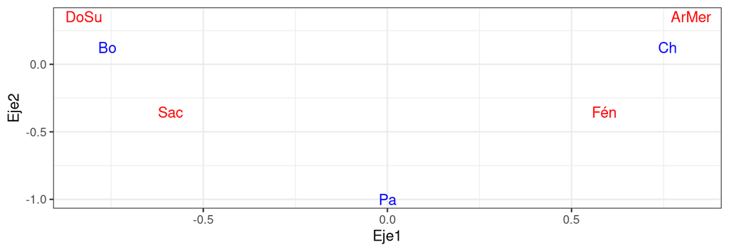

```
##    ArMer DoSu Fén Sac
## Ch     8    1   6   1
## Pa     0    0   2   2
## Bo     1    8   1   6
```

## Contribuciones a la varianza

Además, estos índices se relacionan con cuánto contribuye cada fila y columna a la varianza de cada eje:

```
##   Fila pVe1   pVe2
## 1   Ch  0.5 0.0556
## 2   Pa  0.0 0.8889
## 3   Bo  0.5 0.0556
```

```
##    Fila   pVe1 pVe2
## 1 ArMer 0.3311 0.25
## 2  DoSu 0.3311 0.25
## 3   Fén 0.1689 0.25
## 4   Sac 0.1689 0.25
```

## Ejemplo “independiente”

Varianza explicada

```
##   Autovalores PropVarAcum
## 1      0.1077           1
## 2      0.0000           1
## 3      0.0000           1
```

## Contribuciones

Contribuciones (fila):

```
##   Fila   pVe1   pVe2
## 1   Ch 0.3667 0.6333
## 2   Pa 0.6333 0.3667
## 3   Bo 0.0000 0.0000
```

Contribuciones (columnas):

```
##   Fila   pVe1   pVe2
## 1  Com 0.2667 0.7333
## 2  Exc 0.0222 0.0081
## 3 SpIt 0.4444 0.1616
## 4  UAI 0.2667 0.0970
```

## Representación gráfica

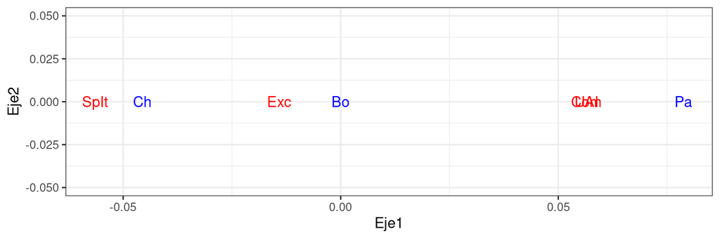

```
##    Com Exc SpIt UAI
## Ch   4   5    6   4
## Pa   2   3    4   2
## Bo   3   4    5   3
```

## Análisis de Multicorrespondencia

## Análisis de Multicorrespondencia

Cuando hay más de dos variables categóricas, realizar una tabla similar a la anterior es más difícil ya que no hay una variable para las “filas” y otra para las columnas. Por lo tanto, se suele hacer lo que se llama una tabla disyuntiva, donde hay una fila por observación y se establece binariamente si la observación pertenece a cada categoría.

```
##       Ch Pa Bo ArMer DoSu Fén Sac Tit Sup
##  [1,]  0  0  1     0    1   0   0   0   1
##  [2,]  1  0  0     1    0   0   0   1   0
##  [3,]  1  0  0     1    0   0   0   1   0
##  [4,]  1  0  0     0    0   1   0   1   0
##  [5,]  0  0  1     0    1   0   0   0   1
##  [6,]  0  0  1     0    0   0   1   0   1
##  [7,]  0  0  1     0    1   0   0   0   1
##  [8,]  0  0  1     0    0   1   0   0   1
##  [9,]  1  0  0     0    0   1   0   1   0
## [10,]  0  0  1     0    0   0   1   0   1
```

## Tabla de Burt

Multiplicando esta matriz por su transpuesta, se puede determinar qué combinaciones hay entre todas las categorías de todas las variables, generando lo que se llama una Tabla de Burt:

```
##       Ch Pa Bo ArMer DoSu Fén Sac Tit Sup
## Ch    16  0  0     8    1   6   1  16   0
## Pa     0  4  0     0    0   2   2   2   2
## Bo     0  0 16     1    8   1   6   0  16
## ArMer  8  0  1     9    0   0   0   8   1
## DoSu   1  0  8     0    9   0   0   1   8
## Fén    6  2  1     0    0   9   0   6   3
## Sac    1  2  6     0    0   0   9   3   6
## Tit   16  2  0     8    1   6   3  18   0
## Sup    0  2 16     1    8   3   6   0  18
```

Notar que hay categorías que no se cruzan, por ejemplo, no hay personas que coman paty y bondiola. Por lo tanto, también da una noción de qué combinaciones son infrecuentes.

## Análisis de Multicorrespondencia

Con esta tabla, podemos aplicar el procedimiento anterior, sólo que ya no diferenciamos filas y columnas. Esto se debe a que tanto las filas como columnas tienen todas las categorías y por lo tanto, hacer el análisis por filas o columnas dará los mismos resultados. Aquí tenemos las desviaciones de la hipótesis de independencia para esta misma tabla:

```
##           Ch     Pa     Bo ArMer  DoSu    Fén    Sac    Tit    Sup
## Ch     3.333 -1.333 -2.667  2.00 -1.50  1.000 -1.500  2.828 -2.828
## Pa    -1.333  5.333 -1.333 -1.00 -1.00  1.000  1.000  0.000  0.000
## Bo    -2.667 -1.333  3.333 -1.50  2.00 -1.500  1.000 -2.828  2.828
## ArMer  2.000 -1.000 -1.500  4.50 -1.50 -1.500 -1.500  1.650 -1.650
## DoSu  -1.500 -1.000  2.000 -1.50  4.50 -1.500 -1.500 -1.650  1.650
## Fén    1.000  1.000 -1.500 -1.50 -1.50  4.500 -1.500  0.707 -0.707
## Sac   -1.500  1.000  1.000 -1.50 -1.50 -1.500  4.500 -0.707  0.707
## Tit    2.828  0.000 -2.828  1.65 -1.65  0.707 -0.707  3.000 -3.000
## Sup   -2.828  0.000  2.828 -1.65  1.65 -0.707  0.707 -3.000  3.000
```

## Autovalores y SVD

Al ser una matriz cuadrada y simétrica, la descomposición en SVD dará lo mismo que una diagonalización ortonormal, y no habrá diferencias entre los autovectores de \(C\times C^T\) y \(C^T\times C\). Por lo tanto, podemos sólo analizar los autovalores de una de ellas para entender el porcentaje de la varianza explicada:

```
##   Autovalores PropVarAcum
## 1    226.8186   0.6447780
## 2     65.9558   0.8322708
## 3     36.7522   0.9367464
## 4     15.0442   0.9795126
## 5      7.1670   0.9998863
## 6      0.0400   1.0000000
## 7      0.0000   1.0000000
## 8      0.0000   1.0000000
## 9      0.0000   1.0000000
```

## Índices

Al ser esta una matriz simétrica, los índices por columna y fila darán lo mismo también. Esto se debe a que se basan en los autovectores \(\vec{u}_k=\vec{v}_k\), donde \(\vec{u}_k\) es el \(k\)-ésimo autovector de \(C\times C^T\), al ser igual a \(C^T\times C\), coincide con \(\vec{v}_k\).

Índices de filas: \(\underset{9\times 1}{\underbrace{\mathbf{r}_k}}=\underset{9\times 9}{\underbrace{A^{-\frac{1}{2}}}} \times \underset{9\times 9}{\underbrace{C}} \times \underset{9\times 1}{\underbrace{\vec{v}_k}}=\sqrt{\lambda_k}\cdot \underset{9\times 9}{\underbrace{A^{-\frac{1}{2}}}} \times \underset{9\times 1}{\underbrace{\vec{v}_k}}\)

La matriz \(A\) se definen a partir de las frecuencias relativas de cada fila: \[A=\text{diag}(N_C,N_P,N_B,N_{AM},N_{DS},N_F,N_S,N_{Tit},N_{Sup}) \]

## Contribuciones

También, podemos ver las contribuciones de cada categoría a los distintos ejes:

```
##    Fila   pVe1   pVe2
## 1    Ch 0.1893 0.0278
## 2    Pa 0.0000 0.4444
## 3    Bo 0.1893 0.0278
## 4 ArMer 0.1024 0.1250
## 5  DoSu 0.1024 0.1250
## 6   Fén 0.0343 0.1250
## 7   Sac 0.0343 0.1250
## 8   Tit 0.1740 0.0000
## 9   Sup 0.1740 0.0000
```

## Representación gráfica

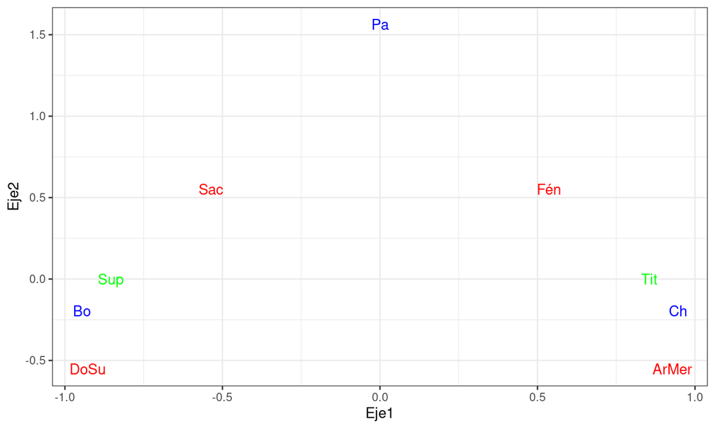